# Current Data Analysis for the Facial Expression/Cortisol Project

Julianna Calabrese

Last updated 1/23/2019

## Introduction

In this file, I do my best to follow the instructions as laid out in Lopez-Duran, Mayer, & Abelson 2014. I wil try to explain all the code written in this file, why I do it, and why things may look weird at times. I will also try to name objects, variables, and models as consistently as possible.

Since Lopez-Duran, Mayer, & Abelson’s 2014 paper utilized the PROC MIXED command in SAS, this RMarkdown file will use the lmer() command as part of the lme4 package. More information about lmer() can be found here: https://cran.r-project.org/web/packages/SASmixed/vignettes/Usinglmer.pdf

## Model building

### Equation from Lopez-Duran 2014

$\begin{aligned} Cortisol = \beta_0 & + (\beta_1 \cdot Sex) \\ & + (\beta_2 \cdot TimeBeforePeak) \\ & + (\beta_3 \cdot TimeAfterPeak) \\ & + (\beta_4 \cdot Sex \cdot TimeBeforePeak) \\ & + (\beta_5 \cdot Sex \cdot TimeAfterPeak) \\ \end{aligned}$

### Definitions

- b0 = intercept aka peak
- b1 = the impact of sex on levels at the group peak time
- b2 = the activation slope for males
- b3 = the regulation slope for males
- b4 = the impact of sex (females) on the activation slope
- b5 = the impact of sex (females) on the regulation slope
- timebeforepeak = the reactivity slope / activation
- timeafterpeak = the recovery slope / regulation

The variable “gender” is a binary variable of 0 = male and 1 = female.

## Model using actual time values

The model below (aka “mod1”) uses variables that were made using the variables “stimeC” and “peaktimenumC”. “stime” is the actual time variable (e.g. 837, 844, 855) and “peaktimenum” is the time when the participant’s cortisol value (“cortvalue”) was highest. Therefore, for all the rows that have ID 10003, each row has a different “stime” value (e.g. 837, 844, 855, …), but each row has the same “peaktimenum” value (e.g. 844, 844, 844, …), indicating that the highest cortisol value was observed at stime 844. “stimeC” is the zero-centered version of “stime” and “peaktimenumC” is the zero-centered version of “peaktimenum”.

The variable “peaknamenum” corresponds to the order in which the sample were taken. For example, for ID 10003, the time at which his cortisol peaked was 844, which was the second sample taken (out of the nine samples related to the SECPT). Therefore, for ID 10003, his “peaknamenum” is “2”.

Therefore, we want “peaknamenum” to be a character, but we want almost everything else to be numeric or an integer.

```r
mod1 <- lmer(cortvalue ~ (gender) + (timebeforepeak) + (timeafterpeak) + (gender*timebeforepeak) + (gender*timeafterpeak) + (1|id) + (1|stimeC), data = cp_long, REML=TRUE)
summary(mod1)
```

Base Model Summary Output (mod1)

|  | Cortisol |  |  |  |
| --- | --- | --- | --- | --- |
| Predictors | Estimates | DF | Standard Error | P-value |
| Intercept | 3.48 | 222.00 | 0.10 | **<0.001** |
| Sex | -0.23 | 221.00 | 0.13 | 0.083 |
| TimeBeforePeak | 0.90 | 1366.00 | 0.07 | **<0.001** |
| TimeAfterPeak | -0.32 | 1426.00 | 0.08 | **<0.001** |
| Sex * TimeBeforePeak | 0.14 | 1496.00 | 0.10 | 0.148 |
| Sex * TimeAfterPeak | -0.11 | 1576.00 | 0.11 | 0.281 |
| Observations | 1665 |  |  |  |
| Marginal R<sup>2</sup> / Conditional R<sup>2</sup> | 0.096 / 0.739 |  |  |  |

In mod1, intercept (aka peak) is significant, as well as TimeBeforePeak and TimeAfterPeak.

## Model using “sample” time values

In my dataset, “samplepeaknamenum” is the variable that corresponds to the nine samples and the amount of minutes after the cold press task: 0, 3, 15, 25, 30, 35, 40, 45, 60.

Like shown above, alternatives include “stime” or “stimeC” (which is stime but zero-centered), which is the actual amount of minutes between each sample (e.g. 837, 844, 855, …) or timenum, which is the mostly just the sample number. timenum is 4, 5, 6, 7, 8, 9, 10, 11, and 12, while timenum is “centered” (not really though–it just assumes that the fourth sample is actually the first sample, since we don’t care about cortisol levels during the MRI) and is 1, 2, 3, 4, 5, 6, 7, 8, and 9.

Therefore, any variable that begins with “sample” is based off this 0, 3, 15, etc. sequence: samplepeaknamenum, sampletimetopeak, sampletimebeforepeak, and sampletimeafterpeak. The reason I went with the “sample” version of the time variable is because we would be able to treat time as a factor instead of as an integer or as a numeric variable.

As opposed to the first model, I believe that the second model is the closest to the model in Lopez-Duran 2014 as possible.

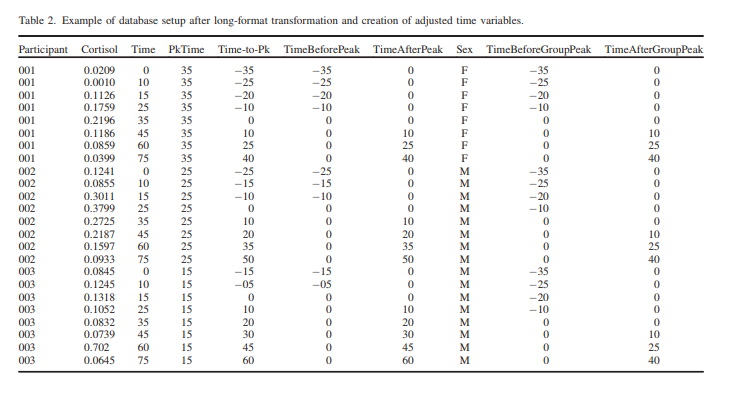

According to Table 2 in Lopez-Duran 2014, there were no “actual time” values (i.e. 837, 844, 855, …), just the “minute” values (i.e. 0, 3, 15, …).

Additionally, in his table, gender is M/F. So I transformed “gender” and “female” from integers to character variables, which makes them identical to a M/F system.

```r
mod2 <- lmer(cortvalue ~ (gender) + (sampletimebeforepeak) + (sampletimeafterpeak) + (gender*sampletimebeforepeak) + (gender*sampletimeafterpeak) + (1|id) + (1|sampletime), data = cp_long, REML=TRUE)
summary(mod2)
```

Base Model Summary Output (mod2)

|  | Cortisol |  |  |  |
| --- | --- | --- | --- | --- |
| Predictors | Estimates | DF | Standard Error | P-value |
| Intercept | 3.52 | 52.00 | 0.12 | **<0.001** |
| Sex | -0.20 | 217.00 | 0.13 | 0.124 |
| TimeBeforePeak | 0.01 | 67.00 | 0.00 | **<0.001** |
| TimeAfterPeak | -0.02 | 111.00 | 0.00 | **<0.001** |
| Sex * TimeBeforePeak | 0.00 | 1519.00 | 0.00 | 0.058 |
| Sex * TimeAfterPeak | -0.00 | 1553.00 | 0.00 | 0.069 |
| Observations | 1665 |  |  |  |
| Marginal R<sup>2</sup> / Conditional R<sup>2</sup> | 0.112 / 0.759 |  |  |  |

In mod2, the intercept, TimeBeforePeak, and TimeAfterPeak are significant. The interactions between gender and slope are bordering significance at p = 0.0579 and 0-.0694 respectively. However, compared to mod1, gender in mod2 is “less significant”.

## Base model findings

Both mod1 and mod2 have significant results, so I will use the anova() function to compare the fit.

```r
pander(anova(mod1, mod2))
```

refitting model(s) with ML (instead of REML)

Data: cp_long

|  | Df | AIC | BIC | logLik | deviance | Chisq | Chi Df | Pr(>Chisq) |
| --- | --- | --- | --- | --- | --- | --- | --- | --- |
| **mod1** | 9 | 3274 | 3323 | -1628 | 3256 | NA | NA | NA |
| **mod2** | 9 | 3097 | 3146 | -1539 | 3079 | 177 | 0 | 0 |

However, it like mod2 has the better fit, so I will abandon mod1 and rename mod2 to ‘base’.

## Base model visualizations

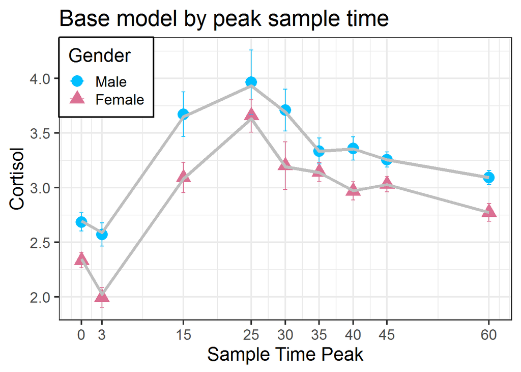

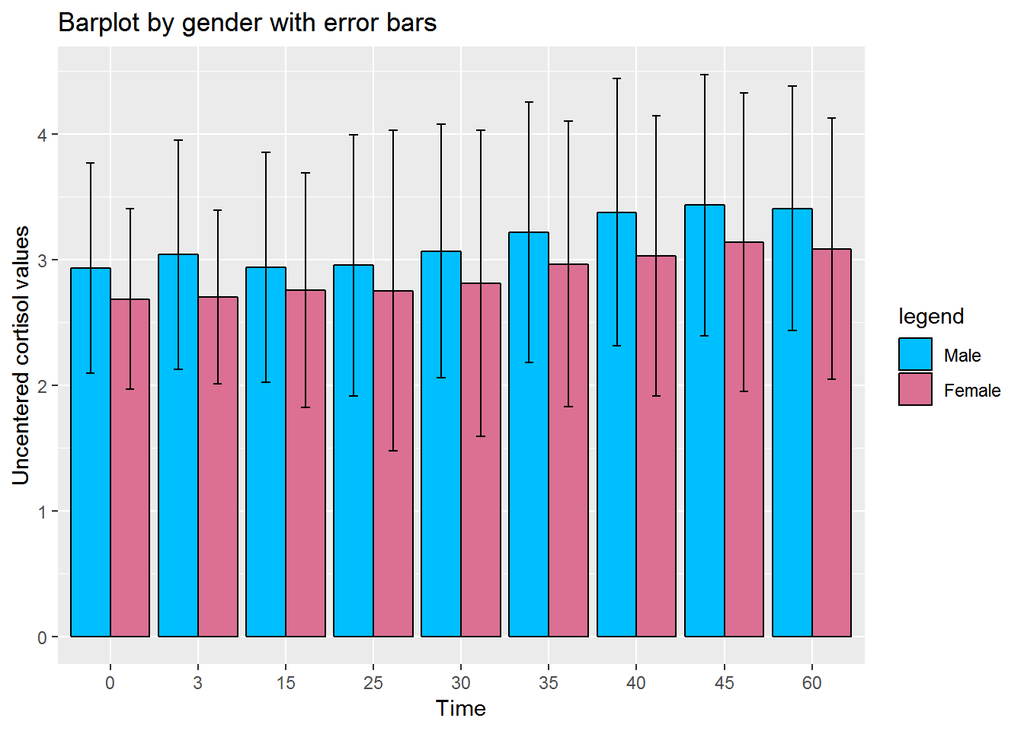

## Basic emotional models

### Anger

```r
anger <- lmer(cortvalue ~ (gender) + (sampletimebeforepeak) + (sampletimeafterpeak) + (gender*sampletimebeforepeak) + (gender*sampletimeafterpeak) + angerC + (1|id) + (1|sampletime), data = cp_long, REML=TRUE)
summary(anger)
```

Anger Model Summary Output

|  | Cortisol |  |  |  |
| --- | --- | --- | --- | --- |
| Predictors | Estimates | DF | Standard Error | P-value |
| Intercept | 3.53 | 52.00 | 0.12 | **<0.001** |
| Sex | -0.20 | 215.00 | 0.13 | 0.113 |
| TimeBeforePeak | 0.01 | 67.00 | 0.00 | **<0.001** |
| TimeAfterPeak | -0.02 | 111.00 | 0.00 | **<0.001** |
| Anger | -0.03 | 181.00 | 0.06 | 0.591 |
| Sex * TimeBeforePeak | 0.00 | 1519.00 | 0.00 | 0.059 |
| Sex * TimeAfterPeak | -0.00 | 1552.00 | 0.00 | 0.068 |
| Observations | 1665 |  |  |  |
| Marginal R<sup>2</sup> / Conditional R<sup>2</sup> | 0.112 / 0.759 |  |  |  |

Anger is not significant.

### Fear

```r
fear <- lmer(cortvalue ~ (gender) + (sampletimebeforepeak) + (sampletimeafterpeak) + (gender*sampletimebeforepeak) + (gender*sampletimeafterpeak) + fearC + (1|id) + (1|sampletime), data = cp_long, REML=TRUE)
summary(fear)
```

Fear Model Summary Output

|  | Cortisol |  |  |  |
| --- | --- | --- | --- | --- |
| Predictors | Estimates | DF | Standard Error | P-value |
| Intercept | 3.53 | 52.00 | 0.12 | **<0.001** |
| Sex | -0.20 | 214.00 | 0.13 | 0.116 |
| TimeBeforePeak | 0.01 | 67.00 | 0.00 | **<0.001** |
| TimeAfterPeak | -0.02 | 110.00 | 0.00 | **<0.001** |
| Fear | -0.03 | 182.00 | 0.06 | 0.681 |
| Sex * TimeBeforePeak | 0.00 | 1519.00 | 0.00 | 0.058 |
| Sex * TimeAfterPeak | -0.00 | 1553.00 | 0.00 | 0.069 |
| Observations | 1665 |  |  |  |
| Marginal R<sup>2</sup> / Conditional R<sup>2</sup> | 0.112 / 0.759 |  |  |  |

Fear is not significant.

### Happiness

```r
happy <- lmer(cortvalue ~ (gender) + (sampletimebeforepeak) + (sampletimeafterpeak) + (gender*sampletimebeforepeak) + (gender*sampletimeafterpeak) + happinessC + (1|id) + (1|sampletime), data = cp_long, REML=TRUE)
summary(happy)
```

Happy Model Summary Output

|  | Cortisol |  |  |  |
| --- | --- | --- | --- | --- |
| Predictors | Estimates | DF | Standard Error | P-value |
| Intercept | 3.53 | 54.00 | 0.12 | **<0.001** |
| Sex | -0.20 | 214.00 | 0.13 | 0.125 |
| TimeBeforePeak | 0.01 | 65.00 | 0.00 | **<0.001** |
| TimeAfterPeak | -0.02 | 107.00 | 0.00 | **<0.001** |
| Happiness | 0.01 | 182.00 | 0.06 | 0.876 |
| Sex * TimeBeforePeak | 0.00 | 1519.00 | 0.00 | 0.058 |
| Sex * TimeAfterPeak | -0.00 | 1553.00 | 0.00 | 0.069 |
| Observations | 1665 |  |  |  |
| Marginal R<sup>2</sup> / Conditional R<sup>2</sup> | 0.111 / 0.759 |  |  |  |

Happiness is not significant.

### Sadness

```r
sad <- lmer(cortvalue ~ (gender) + (sampletimebeforepeak) + (sampletimeafterpeak) + (gender*sampletimebeforepeak) + (gender*sampletimeafterpeak) + sadnessC + (1|id) + (1|sampletime), data = cp_long, REML=TRUE)
summary(sad)
```

Sad Model Summary Output

|  | Cortisol |  |  |  |
| --- | --- | --- | --- | --- |
| Predictors | Estimates | DF | Standard Error | P-value |
| Intercept | 3.53 | 53.00 | 0.12 | **<0.001** |
| Sex | -0.20 | 215.00 | 0.13 | 0.119 |
| TimeBeforePeak | 0.01 | 66.00 | 0.00 | **<0.001** |
| TimeAfterPeak | -0.02 | 110.00 | 0.00 | **<0.001** |
| Sadness | -0.06 | 181.00 | 0.06 | 0.365 |
| Sex * TimeBeforePeak | 0.00 | 1519.00 | 0.00 | 0.059 |
| Sex * TimeAfterPeak | -0.00 | 1553.00 | 0.00 | 0.070 |
| Observations | 1665 |  |  |  |
| Marginal R<sup>2</sup> / Conditional R<sup>2</sup> | 0.113 / 0.759 |  |  |  |

Sadness is not significant.

### Pain

```r
pain <- lmer(cortvalue ~ (gender) + (sampletimebeforepeak) + (sampletimeafterpeak) + (gender*sampletimebeforepeak) + (gender*sampletimeafterpeak) + painC + (1|id) + (1|sampletime), data = cp_long, REML=TRUE)
summary(pain)
```

Pain Model Summary Output

|  | Cortisol |  |  |  |
| --- | --- | --- | --- | --- |
| Predictors | Estimates | DF | Standard Error | P-value |
| Intercept | 3.53 | 52.00 | 0.12 | **<0.001** |
| Sex | -0.20 | 215.00 | 0.13 | 0.119 |
| TimeBeforePeak | 0.01 | 67.00 | 0.00 | **<0.001** |
| TimeAfterPeak | -0.02 | 111.00 | 0.00 | **<0.001** |
| Pain | -0.03 | 182.00 | 0.06 | 0.625 |
| Sex * TimeBeforePeak | 0.00 | 1519.00 | 0.00 | 0.058 |
| Sex * TimeAfterPeak | -0.00 | 1553.00 | 0.00 | 0.069 |
| Observations | 1665 |  |  |  |
| Marginal R<sup>2</sup> / Conditional R<sup>2</sup> | 0.112 / 0.759 |  |  |  |

Pain is not significant.

## Basic emotion model conclusions

From first glance, it looks like none of the emotions have reached the alpha < 0.05 threshold as predictors. Now I will compare which models have better fit than the others.

```r
pander(anova(base, anger, fear, happy, sad, pain))
```

refitting model(s) with ML (instead of REML)

Data: cp_long

|  | Df | AIC | BIC | logLik | deviance | Chisq | Chi Df | Pr(>Chisq) |
| --- | --- | --- | --- | --- | --- | --- | --- | --- |
| **base** | 9 | 3097 | 3146 | -1539 | 3079 | NA | NA | NA |
| **anger** | 10 | 3099 | 3153 | -1539 | 3079 | 0.2815 | 1 | 0.5957 |
| **fear** | 10 | 3099 | 3153 | -1539 | 3079 | 0 | 0 | 1 |
| **happy** | 10 | 3099 | 3153 | -1539 | 3079 | 0 | 0 | 1 |
| **sad** | 10 | 3098 | 3152 | -1539 | 3078 | 0.8092 | 0 | 0 |
| **pain** | 10 | 3099 | 3153 | -1539 | 3079 | 0 | 0 | 1 |

Compared to the base model, the sad model significantly fits better. The only other model that comes close is anger with p = 0.5957.

```r
pander(anova(base, sad))
```

refitting model(s) with ML (instead of REML)

Data: cp_long

|  | Df | AIC | BIC | logLik | deviance | Chisq | Chi Df | Pr(>Chisq) |
| --- | --- | --- | --- | --- | --- | --- | --- | --- |
| **base** | 9 | 3097 | 3146 | -1539 | 3079 | NA | NA | NA |
| **sad** | 10 | 3098 | 3152 | -1539 | 3078 | 0.8413 | 1 | 0.359 |

If the basic sad model is compared to the base model, sad loses its significance.

```r
pander(anova(anger, fear, happy, sad, pain))
```

refitting model(s) with ML (instead of REML)

Data: cp_long

|  | Df | AIC | BIC | logLik | deviance | Chisq | Chi Df | Pr(>Chisq) |
| --- | --- | --- | --- | --- | --- | --- | --- | --- |
| **anger** | 10 | 3099 | 3153 | -1539 | 3079 | NA | NA | NA |
| **fear** | 10 | 3099 | 3153 | -1539 | 3079 | 0 | 0 | 1 |
| **happy** | 10 | 3099 | 3153 | -1539 | 3079 | 0 | 0 | 1 |
| **sad** | 10 | 3098 | 3152 | -1539 | 3078 | 0.8092 | 0 | 0 |
| **pain** | 10 | 3099 | 3153 | -1539 | 3079 | 0 | 0 | 1 |

If you remove the base model and only compare the basic emotion models with each (i.e. anger, fear, happy, sad, and pain), sad remains significant.

Base Model vs. Basic Sad Model

|  | Base |  |  |  | Sadness |  |  |  |
| --- | --- | --- | --- | --- | --- | --- | --- | --- |
| Predictors | Estimates | DF | Standard Error | P-value | Estimates | DF | Standard Error | P-value |
| Intercept | 3.52 | 52.00 | 0.12 | **<0.001** | 3.53 | 53.00 | 0.12 | **<0.001** |
| Sex | -0.20 | 217.00 | 0.13 | 0.124 | -0.20 | 215.00 | 0.13 | 0.119 |
| TimeBeforePeak | 0.01 | 67.00 | 0.00 | **<0.001** | 0.01 | 66.00 | 0.00 | **<0.001** |
| TimeAfterPeak | -0.02 | 111.00 | 0.00 | **<0.001** | -0.02 | 110.00 | 0.00 | **<0.001** |
| Sex * TimeBeforePeak | 0.00 | 1519.00 | 0.00 | 0.058 | 0.00 | 1519.00 | 0.00 | 0.059 |
| Sex * TimeAfterPeak | -0.00 | 1553.00 | 0.00 | 0.069 | -0.00 | 1553.00 | 0.00 | 0.070 |
| Sadness |  |  |  |  | -0.06 | 181.00 | 0.06 | 0.365 |
| Observations | 1665 |  |  |  | 1665 |  |  |  |
| Marginal R<sup>2</sup> / Conditional R<sup>2</sup> | 0.112 / 0.759 |  |  |  | 0.113 / 0.759 |  |  |  |

Even though sadness is not significant in the sad model, its presence somehow makes the model fit better compared to the base model and other emotion models. But by just comparing it to the base model, sad does not significantly improve model fit.

### Basic sad model visualization

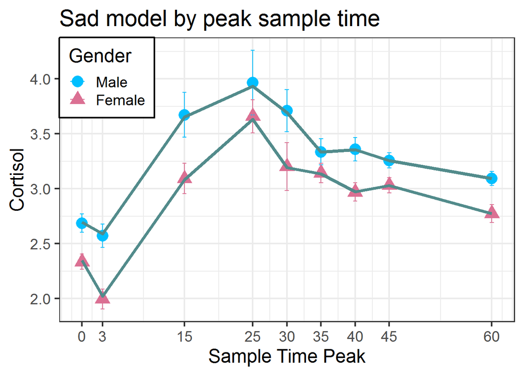

## Emotion models with interaction

As suggested by Dr. Lopez-Duran on 1/22/19, I should add interaction to the emotion models, i.e. Anger x TimeBeforePeak and Anger x TimeAfterPeak. When creating the below models, I also tried adding Emotion x TimeBeforePeak x TimeAfterPeak, but since that ended up being redunant/non-significant, the idea was dropped.

### Anger with Interaction

```r
anger_x <- lmer(cortvalue ~ (gender) + (sampletimebeforepeak) + (sampletimeafterpeak) + (gender*sampletimebeforepeak) + (gender*sampletimeafterpeak) + angerC + (angerC*gender) + (angerC*sampletimebeforepeak) + (angerC*sampletimeafterpeak) + (1|id) + (1|sampletime), data = cp_long, REML=TRUE)
summary(anger_x)
```

AngerX Model Summary Output

|  | Cortisol |  |  |  |
| --- | --- | --- | --- | --- |
| Predictors | Estimates | DF | Standard Error | P-value |
| Intercept | 3.53 | 53.00 | 0.12 | **<0.001** |
| Sex | -0.21 | 214.00 | 0.13 | 0.104 |
| TimeBeforePeak | 0.01 | 66.00 | 0.00 | **<0.001** |
| TimeAfterPeak | -0.02 | 109.00 | 0.00 | **<0.001** |
| Anger | -0.07 | 196.00 | 0.09 | 0.448 |
| Sex * TimeBeforePeak | 0.00 | 1516.00 | 0.00 | 0.072 |
| Sex * TimeAfterPeak | -0.00 | 1551.00 | 0.00 | 0.113 |
| Sex * Anger | 0.03 | 181.00 | 0.12 | 0.827 |
| TimeBeforePeak * Anger | -0.00 | 1512.00 | 0.00 | 0.332 |
| TimeAfterPeak * Anger | 0.00 | 1546.00 | 0.00 | 0.364 |
| Observations | 1665 |  |  |  |
| Marginal R<sup>2</sup> / Conditional R<sup>2</sup> | 0.112 / 0.760 |  |  |  |

Anger and its interactions are not significant.

### Fear with Interaction

```r
fear_x <- lmer(cortvalue ~ (gender) + (sampletimebeforepeak) + (sampletimeafterpeak) + (gender*sampletimebeforepeak) + (gender*sampletimeafterpeak) + fearC + (fearC*gender) + (fearC*sampletimebeforepeak) + (fearC*sampletimeafterpeak) + (1|id) + (1|sampletime), data = cp_long, REML=TRUE)
summary(fear_x)
```

FearX Model Summary Output

|  | Cortisol |  |  |  |
| --- | --- | --- | --- | --- |
| Predictors | Estimates | DF | Standard Error | P-value |
| Intercept | 3.53 | 53.00 | 0.12 | **<0.001** |
| Sex | -0.21 | 214.00 | 0.13 | 0.106 |
| TimeBeforePeak | 0.01 | 67.00 | 0.00 | **<0.001** |
| TimeAfterPeak | -0.02 | 110.00 | 0.00 | **<0.001** |
| Fear | -0.06 | 195.00 | 0.09 | 0.542 |
| Sex * TimeBeforePeak | 0.00 | 1516.00 | 0.00 | 0.082 |
| Sex * TimeAfterPeak | -0.00 | 1550.00 | 0.00 | 0.092 |
| Sex * Fear | 0.02 | 180.00 | 0.12 | 0.890 |
| TimeBeforePeak * Fear | -0.00 | 1518.00 | 0.00 | 0.253 |
| TimeAfterPeak * Fear | 0.00 | 1546.00 | 0.00 | 0.467 |
| Observations | 1665 |  |  |  |
| Marginal R<sup>2</sup> / Conditional R<sup>2</sup> | 0.111 / 0.760 |  |  |  |

Fear and its interactions are not significant.

### Happiness with Interaction

```r
happy_x <- lmer(cortvalue ~ (gender) + (sampletimebeforepeak) + (sampletimeafterpeak) + (gender*sampletimebeforepeak) + (gender*sampletimeafterpeak) + happinessC + (happinessC*gender) + (happinessC*sampletimebeforepeak) + (happinessC*sampletimeafterpeak) + (1|id) + (1|sampletime), data = cp_long, REML=TRUE)
summary(happy_x)
```

HappyX Model Summary Output

|  | Cortisol |  |  |  |
| --- | --- | --- | --- | --- |
| Predictors | Estimates | DF | Standard Error | P-value |
| Intercept | 3.50 | 54.00 | 0.12 | **<0.001** |
| Sex | -0.18 | 214.00 | 0.13 | 0.167 |
| TimeBeforePeak | 0.01 | 67.00 | 0.00 | **<0.001** |
| TimeAfterPeak | -0.02 | 117.00 | 0.00 | **<0.001** |
| Happiness | -0.10 | 194.00 | 0.10 | 0.328 |
| Sex * TimeBeforePeak | 0.00 | 1516.00 | 0.00 | 0.053 |
| Sex * TimeAfterPeak | -0.01 | 1548.00 | 0.00 | **0.023** |
| Sex * Happiness | 0.14 | 181.00 | 0.13 | 0.287 |
| TimeBeforePeak * Happiness | -0.00 | 1503.00 | 0.00 | 0.819 |
| TimeAfterPeak * Happiness | 0.00 | 1549.00 | 0.00 | **0.022** |
| Observations | 1665 |  |  |  |
| Marginal R<sup>2</sup> / Conditional R<sup>2</sup> | 0.117 / 0.761 |  |  |  |

In the happy interaction model, the interaction between gender and TimeAfterPeak is significant, as well as the interaction between happiness and TimeAfterPeak with = 0.0218.

### Sadness with Interaction

```r
sad_x <- lmer(cortvalue ~ (gender) + (sampletimebeforepeak) + (sampletimeafterpeak) + (gender*sampletimebeforepeak) + (gender*sampletimeafterpeak) + sadnessC + (sadnessC*gender) + (sadnessC*sampletimebeforepeak) + (sadnessC*sampletimeafterpeak) + (1|id) + (1|sampletime), data = cp_long, REML=TRUE)
summary(sad_x)
```

SadX Model Summary Output

[output not shown]

Sadness and its interactions are not significant.

### Pain with Interaction

```r
pain_x <- lmer(cortvalue ~ (gender) + (sampletimebeforepeak) + (sampletimeafterpeak) + (gender*sampletimebeforepeak) + (gender*sampletimeafterpeak) + painC + (painC*gender) + (painC*sampletimebeforepeak) + (painC*sampletimeafterpeak) + (1|id) + (1|sampletime), data = cp_long, REML=TRUE)
summary(pain_x)
```

PainX Model Summary Output

|  | Cortisol |  |  |  |
| --- | --- | --- | --- | --- |
| Predictors | Estimates | DF | Standard Error | P-value |
| Intercept | 3.53 | 52.00 | 0.12 | **<0.001** |
| Sex | -0.21 | 214.00 | 0.13 | 0.107 |
| TimeBeforePeak | 0.01 | 68.00 | 0.00 | **<0.001** |
| TimeAfterPeak | -0.02 | 111.00 | 0.00 | **<0.001** |
| Pain | -0.13 | 194.00 | 0.10 | 0.196 |
| Sex * TimeBeforePeak | 0.00 | 1516.00 | 0.00 | 0.066 |
| Sex * TimeAfterPeak | -0.00 | 1551.00 | 0.00 | 0.099 |
| Sex * Pain | 0.11 | 180.00 | 0.12 | 0.372 |
| TimeBeforePeak * Pain | -0.00 | 1511.00 | 0.00 | 0.170 |
| TimeAfterPeak * Pain | 0.00 | 1546.00 | 0.00 | 0.189 |
| Observations | 1665 |  |  |  |
| Marginal R<sup>2</sup> / Conditional R<sup>2</sup> | 0.115 / 0.761 |  |  |  |

Pain and its interactions are not significant.

## Emotion models with interactions conclusions

In the basic emotion models (without interactions), the only interesting predictor was sadness, which was not a significant predictor in its model, but demonstrated better fit compared to the other models with the anova() function. However, when I solely compared the basic sad model with the base model, sadness lost its significance.

In the above tables, the most interesting predictor was happiness. In the happy interaction model, happiness was not a significant predictor (p = 0.3273), but the interaction between happiness and TimeAfterPeak was significant (p = 0.0218). There was also an interaction between gender and TimeAfterPeak, which was not seen in previous models, although the interaction between gender and happiness was not observed (p = 0.2870).

```r
pander(anova(base, happy_x))
```

```
## refitting model(s) with ML (instead of REML)
```

Data: cp_long

|  | Df | AIC | BIC | logLik | deviance | Chisq | Chi Df | Pr(>Chisq) |
| --- | --- | --- | --- | --- | --- | --- | --- | --- |
| **base** | 9 | 3097 | 3146 | -1539 | 3079 | NA | NA | NA |
| **happy_x** | 13 | 3098 | 3169 | -1536 | 3072 | 6.655 | 4 | 0.1553 |

When you solely compared the happy interaction model to base, neither models have significantly better fit.

```r
pander(anova(anger, anger_x))
```

```
## refitting model(s) with ML (instead of REML)
```

Data: cp_long

|  | Df | AIC | BIC | logLik | deviance | Chisq | Chi Df | Pr(>Chisq) |
| --- | --- | --- | --- | --- | --- | --- | --- | --- |
| **anger** | 10 | 3099 | 3153 | -1539 | 3079 | NA | NA | NA |
| **anger_x** | 13 | 3103 | 3174 | -1539 | 3077 | 1.51 | 3 | 0.6799 |

```r
pander(anova(fear, fear_x))
```

```
## refitting model(s) with ML (instead of REML)
```

Data: cp_long

|  | Df | AIC | BIC | logLik | deviance | Chisq | Chi Df | Pr(>Chisq) |
| --- | --- | --- | --- | --- | --- | --- | --- | --- |
| **fear** | 10 | 3099 | 3153 | -1539 | 3079 | NA | NA | NA |
| **fear_x** | 13 | 3103 | 3174 | -1539 | 3077 | 1.576 | 3 | 0.6648 |

```r
pander(anova(happy, happy_x))
```

```
## refitting model(s) with ML (instead of REML)
```

Data: cp_long

|  | Df | AIC | BIC | logLik | deviance | Chisq | Chi Df | Pr(>Chisq) |
| --- | --- | --- | --- | --- | --- | --- | --- | --- |
| **happy** | 10 | 3099 | 3153 | -1539 | 3079 | NA | NA | NA |
| **happy_x** | 13 | 3098 | 3169 | -1536 | 3072 | 6.623 | 3 | 0.08494 |

```r
pander(anova(sad, sad_x))
```

```
## refitting model(s) with ML (instead of REML)
```

Data: cp_long

|  | Df | AIC | BIC | logLik | deviance | Chisq | Chi Df | Pr(>Chisq) |
| --- | --- | --- | --- | --- | --- | --- | --- | --- |
| **sad** | 10 | 3098 | 3152 | -1539 | 3078 | NA | NA | NA |
| **sad_x** | 13 | 3102 | 3173 | -1538 | 3076 | 1.853 | 3 | 0.6034 |

```r
pander(anova(pain, pain_x))
```

```
## refitting model(s) with ML (instead of REML)
```

Data: cp_long

|  | Df | AIC | BIC | logLik | deviance | Chisq | Chi Df | Pr(>Chisq) |
| --- | --- | --- | --- | --- | --- | --- | --- | --- |
| **pain** | 10 | 3099 | 3153 | -1539 | 3079 | NA | NA | NA |
| **pain_x** | 13 | 3101 | 3171 | -1537 | 3075 | 3.747 | 3 | 0.2901 |

However, when you compare a basic emotion model to its version with interactions, the only comparison that borders significance in happy with p = 0.08494.

### Interaction model visualizations

## Happy interaction model visualization

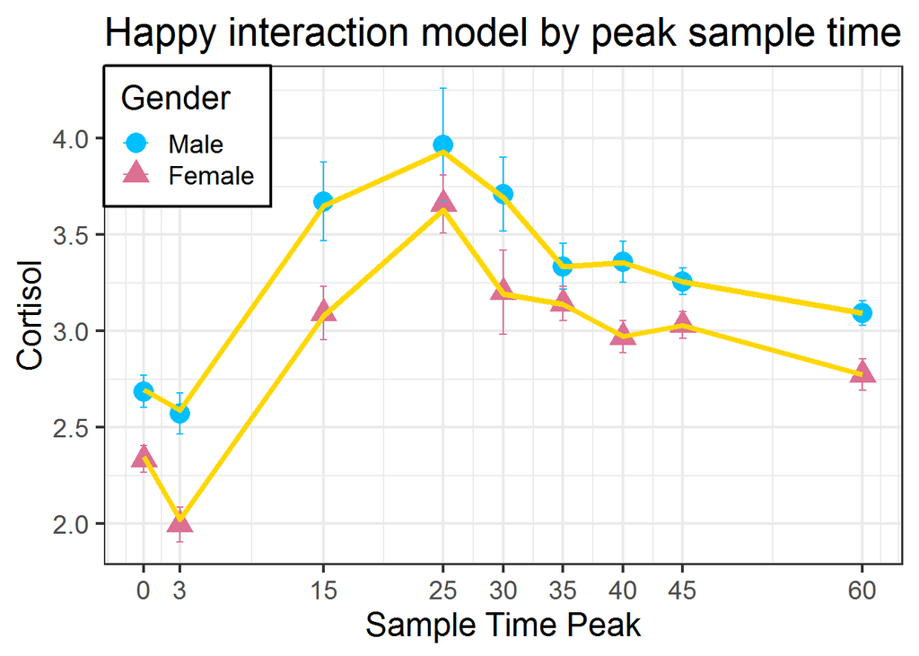

## Adding CTQ to models with and without interaction

Since the original proposal references the importance of trauma, l will add CTQ Total Sum (centered) to see if it makes a difference. Here is the CTQ base model.

### CTQ base model

```r
ctq <- lmer(cortvalue ~ (gender) + (sampletimebeforepeak) + (sampletimeafterpeak) + (gender*sampletimebeforepeak) + (gender*sampletimeafterpeak) + ctqsumC + (1|id) + (1|sampletime), data = cp_long, REML=TRUE)
summary(ctq)
```

Basic CTQ Model Summary Output

|  | Cortisol |  |  |  |
| --- | --- | --- | --- | --- |
| Predictors | Estimates | DF | Standard Error | P-value |
| Intercept | 3.52 | 54.00 | 0.12 | **<0.001** |
| Sex | -0.19 | 215.00 | 0.13 | 0.135 |
| TimeBeforePeak | 0.01 | 65.00 | 0.00 | **<0.001** |
| TimeAfterPeak | -0.02 | 109.00 | 0.00 | **<0.001** |
| CTQ Total Sum | 0.07 | 181.00 | 0.06 | 0.262 |
| Sex * TimeBeforePeak | 0.00 | 1519.00 | 0.00 | 0.059 |
| Sex * TimeAfterPeak | -0.00 | 1553.00 | 0.00 | 0.070 |
| Observations | 1665 |  |  |  |
| Marginal R<sup>2</sup> / Conditional R<sup>2</sup> | 0.117 / 0.760 |  |  |  |

When CTQ is added, Sex X TimeBeforePeak and Sex X TimeAfterPeak remain close to significance, but not quiet yet. Let’s now add CTQ interactions to the above model.

```r
pander(anova(base, ctq))
```

refitting model(s) with ML (instead of REML)

Data: cp_long

|  | Df | AIC | BIC | logLik | deviance | Chisq | Chi Df | Pr(>Chisq) |
| --- | --- | --- | --- | --- | --- | --- | --- | --- |
| **base** | 9 | 3097 | 3146 | -1539 | 3079 | NA | NA | NA |
| **ctq** | 10 | 3098 | 3152 | -1539 | 3078 | 1.299 | 1 | 0.2545 |

The basic CTQ model isn’t that much better than the base model.

### CTQ interaction model

```r
ctq_x <- lmer(cortvalue ~ (gender) + (sampletimebeforepeak) + (sampletimeafterpeak) + (gender*sampletimebeforepeak) + (gender*sampletimeafterpeak) + ctqsumC + (ctqsumC*gender) + (ctqsumC*sampletimebeforepeak) + (ctqsumC*sampletimeafterpeak) + (1|id) + (1|sampletime), data = cp_long, REML=TRUE)
summary(ctq_x)
```

CTQX Model Summary Output

|  | Cortisol |  |  |  |
| --- | --- | --- | --- | --- |
| Predictors | Estimates | DF | Standard Error | P-value |
| Intercept | 3.52 | 52.00 | 0.12 | **<0.001** |
| Sex | -0.19 | 214.00 | 0.13 | 0.146 |
| TimeBeforePeak | 0.01 | 67.00 | 0.00 | **<0.001** |
| TimeAfterPeak | -0.02 | 111.00 | 0.00 | **<0.001** |
| CTQ Total Sum | 0.06 | 196.00 | 0.10 | 0.524 |
| Sex * TimeBeforePeak | 0.00 | 1517.00 | 0.00 | **0.037** |
| Sex * TimeAfterPeak | -0.00 | 1549.00 | 0.00 | **0.047** |
| Sex * CTQ | 0.10 | 181.00 | 0.12 | 0.417 |
| TimeBeforePeak * CTQ | 0.00 | 1507.00 | 0.00 | **0.024** |
| TimeAfterPeak * CTQ | -0.00 | 1529.00 | 0.00 | **0.023** |
| Observations | 1665 |  |  |  |
| Marginal R<sup>2</sup> / Conditional R<sup>2</sup> | 0.122 / 0.762 |  |  |  |

When CTQ Total Sum and its interactions are added to the base model, the following pieces become significant:

- TimeBeforePeak
- TimeAfterPeak
- Sex X TimeBeforePeak
- Sex X TimeAfterPeak
- CTQ X TimeBeforePeak
- CTQ X TimeAfterPeak

```r
pander(anova(base, ctq, ctq_x))
```

refitting model(s) with ML (instead of REML)

Data: cp_long

|  | Df | AIC | BIC | logLik | deviance | Chisq | Chi Df | Pr(>Chisq) |
| --- | --- | --- | --- | --- | --- | --- | --- | --- |
| **base** | 9 | 3097 | 3146 | -1539 | 3079 | NA | NA | NA |
| **ctq** | 10 | 3098 | 3152 | -1539 | 3078 | 1.299 | 1 | 0.2545 |
| **ctq_x** | 13 | 3095 | 3165 | -1534 | 3069 | 8.95 | 3 | 0.02996 |

According to the anova() function, adding the CTQ interactions improves model fit better compared than the base model and the CTQ model without interactions.

## CTQ and emotion models plus interaction

Let’s see if combining emotion and CTQ into one model will make a difference.

### Anger, CTQ, and their interactions

[output not shown]

```r
pander(anova(base, anger, anger_x, angerctq_x))
```

refitting model(s) with ML (instead of REML)

Data: cp_long

|  | Df | AIC | BIC | logLik | deviance | Chisq | Chi Df | Pr(>Chisq) |
| --- | --- | --- | --- | --- | --- | --- | --- | --- |
| **base** | 9 | 3097 | 3146 | -1539 | 3079 | NA | NA | NA |
| **anger** | 10 | 3099 | 3153 | -1539 | 3079 | 0.2815 | 1 | 0.5957 |
| **anger_x** | 13 | 3103 | 3174 | -1539 | 3077 | 1.51 | 3 | 0.6799 |
| **angerctq_x** | 18 | 3103 | 3201 | -1534 | 3067 | 9.759 | 5 | 0.08234 |

### Fear, CTQ, and their interactions

[output not shown]

```r
pander(anova(base, fear, fear_x, fearctq_x))
```

refitting model(s) with ML (instead of REML)

Data: cp_long

|  | Df | AIC | BIC | logLik | deviance | Chisq | Chi Df | Pr(>Chisq) |
| --- | --- | --- | --- | --- | --- | --- | --- | --- |
| **base** | 9 | 3097 | 3146 | -1539 | 3079 | NA | NA | NA |
| **fear** | 10 | 3099 | 3153 | -1539 | 3079 | 0.159 | 1 | 0.6901 |
| **fear_x** | 13 | 3103 | 3174 | -1539 | 3077 | 1.576 | 3 | 0.6648 |
| **fearctq_x** | 18 | 3103 | 3201 | -1534 | 3067 | 9.674 | 5 | 0.08503 |

### Happiness, CTQ, and their interactions

[output not shown]

```r
pander(anova(base, happy, happy_x, happyctq_x))
```

refitting model(s) with ML (instead of REML)

Data: cp_long

|  | Df | AIC | BIC | logLik | deviance | Chisq | Chi Df | Pr(>Chisq) |
| --- | --- | --- | --- | --- | --- | --- | --- | --- |
| **base** | 9 | 3097 | 3146 | -1539 | 3079 | NA | NA | NA |
| **happy** | 10 | 3099 | 3153 | -1539 | 3079 | 0.03213 | 1 | 0.8577 |
| **happy_x** | 13 | 3098 | 3169 | -1536 | 3072 | 6.623 | 3 | 0.08494 |
| **happyctq_x** | 18 | 3098 | 3196 | -1531 | 3062 | 10.24 | 5 | 0.0687 |

### Sadness, CTQ, and their interactions

[output not shown]

```r
pander(anova(base, sad, sad_x, sadctq_x))
```

refitting model(s) with ML (instead of REML)

Data: cp_long

|  | Df | AIC | BIC | logLik | deviance | Chisq | Chi Df | Pr(>Chisq) |
| --- | --- | --- | --- | --- | --- | --- | --- | --- |
| **base** | 9 | 3097 | 3146 | -1539 | 3079 | NA | NA | NA |
| **sad** | 10 | 3098 | 3152 | -1539 | 3078 | 0.8413 | 1 | 0.359 |
| **sad_x** | 13 | 3102 | 3173 | -1538 | 3076 | 1.853 | 3 | 0.6034 |
| **sadctq_x** | 18 | 3102 | 3200 | -1533 | 3066 | 9.908 | 5 | 0.07788 |

### Pain, CTQ, and their interactions

[output not shown]

```r
pander(anova(base, pain, pain_x, painctq_x))
```

refitting model(s) with ML (instead of REML)

Data: cp_long

|  | Df | AIC | BIC | logLik | deviance | Chisq | Chi Df | Pr(>Chisq) |
| --- | --- | --- | --- | --- | --- | --- | --- | --- |
| **base** | 9 | 3097 | 3146 | -1539 | 3079 | NA | NA | NA |
| **pain** | 10 | 3099 | 3153 | -1539 | 3079 | 0.224 | 1 | 0.636 |
| **pain_x** | 13 | 3101 | 3171 | -1537 | 3075 | 3.747 | 3 | 0.2901 |
| **painctq_x** | 18 | 3101 | 3199 | -1533 | 3065 | 9.447 | 5 | 0.0925 |